# Risk Factor Analysis

## Outcome Variable

**Outcome Variable:** whz

## Predictor Variables

**Intervention Variable:** fhtcm

**Adjustment Set:**

- arm
- W_mage
- W_fage
- meducyrs
- feducyrs
- W_mhtcm
- W_mwtkg
- W_mbmi
- single
- W_gagebrth
- W_birthwt
- W_birthlen
- vagbrth
- delta_W_mage
- delta_W_fage
- delta_meducyrs
- delta_feducyrs
- delta_W_mhtcm
- delta_W_mwtkg
- delta_W_mbmi
- delta_single
- delta_W_gagebrth
- delta_W_birthwt
- delta_W_birthlen
- delta_vagbrth

## Stratifying Variables

The analysis was stratified on these variable(s):

- agecat
- studyid
- country

## Data Summary

| agecat | studyid | country | fhtcm | n_cell | n | outcome_variable |
| --- | --- | --- | --- | --- | --- | --- |
| 6 months | ki1000304b-SAS-CompFeed | INDIA | >=167 cm | 370 | 807 | whz |
| 6 months | ki1000304b-SAS-CompFeed | INDIA | <162 cm | 193 | 807 | whz |
| 6 months | ki1000304b-SAS-CompFeed | INDIA | [162-167) cm | 244 | 807 | whz |
| 6 months | ki1000304b-SAS-FoodSuppl | INDIA | >=167 cm | 102 | 371 | whz |
| 6 months | ki1000304b-SAS-FoodSuppl | INDIA | <162 cm | 148 | 371 | whz |
| 6 months | ki1000304b-SAS-FoodSuppl | INDIA | [162-167) cm | 121 | 371 | whz |
| 6 months | ki1101329-Keneba | GAMBIA | >=167 cm | 979 | 1510 | whz |
| 6 months | ki1101329-Keneba | GAMBIA | <162 cm | 113 | 1510 | whz |
| 6 months | ki1101329-Keneba | GAMBIA | [162-167) cm | 418 | 1510 | whz |
| 6 months | ki1119695-PROBIT | BELARUS | >=167 cm | 11143 | 11892 | whz |
| 6 months | ki1119695-PROBIT | BELARUS | <162 cm | 156 | 11892 | whz |
| 6 months | ki1119695-PROBIT | BELARUS | [162-167) cm | 593 | 11892 | whz |
| 6 months | ki1135781-COHORTS | GUATEMALA | >=167 cm | 44 | 336 | whz |
| 6 months | ki1135781-COHORTS | GUATEMALA | <162 cm | 198 | 336 | whz |
| 6 months | ki1135781-COHORTS | GUATEMALA | [162-167) cm | 94 | 336 | whz |
| 24 months | ki1101329-Keneba | GAMBIA | >=167 cm | 823 | 1298 | whz |
| 24 months | ki1101329-Keneba | GAMBIA | <162 cm | 96 | 1298 | whz |
| 24 months | ki1101329-Keneba | GAMBIA | [162-167) cm | 379 | 1298 | whz |
| 24 months | ki1119695-PROBIT | BELARUS | >=167 cm | 3388 | 3610 | whz |
| 24 months | ki1119695-PROBIT | BELARUS | <162 cm | 52 | 3610 | whz |
| 24 months | ki1119695-PROBIT | BELARUS | [162-167) cm | 170 | 3610 | whz |
| 24 months | ki1135781-COHORTS | GUATEMALA | >=167 cm | 72 | 532 | whz |
| 24 months | ki1135781-COHORTS | GUATEMALA | <162 cm | 311 | 532 | whz |
| 24 months | ki1135781-COHORTS | GUATEMALA | [162-167) cm | 149 | 532 | whz |

The following strata were considered:

- agecat: 24 months, studyid: ki1101329-Keneba, country: GAMBIA
- agecat: 24 months, studyid: ki1119695-PROBIT, country: BELARUS
- agecat: 24 months, studyid: ki1135781-COHORTS, country: GUATEMALA
- agecat: 6 months, studyid: ki1000304b-SAS-CompFeed, country: INDIA
- agecat: 6 months, studyid: ki1000304b-SAS-FoodSuppl, country: INDIA
- agecat: 6 months, studyid: ki1101329-Keneba, country: GAMBIA
- agecat: 6 months, studyid: ki1119695-PROBIT, country: BELARUS
- agecat: 6 months, studyid: ki1135781-COHORTS, country: GUATEMALA

## Methods Detail

We’re interested in the causal parameters $E[Y_a]$ for all values of $a \in \mathcal{A}$. These parameters represent the mean outcome if, possibly contrary to fact, we intervened to set all units to have $A=a$. Under the randomization and positivity assumptions, these are identified by the statistical parameters $\psi_a=E_W[E_{Y|A,W}(Y|A=a,W)]$. In addition, we’re interested in the mean of $Y$, $E[Y]$ under no intervention (the observed mean). We will estimate these parameters by using SuperLearner to fit the relevant likelihood factors – $E_{Y|A,W}(Y|A=a,W)$ and $p(A=a|W)$, and then updating our likelihood fit using a joint TMLE.

For unadjusted analyses ($W=\{\}$), initial likelihoods were estimated using Lrnr_glm to estimate the simple $E(Y|A)$ and Lrnr_mean to estimate $p(A)$. For adjusted analyses, a small library containing Lrnr_glmnet, Lrnr_xgboost, and Lrnr_mean was used.

# Results Detail

## Results Plots

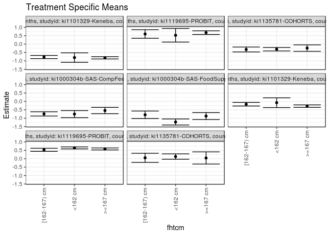

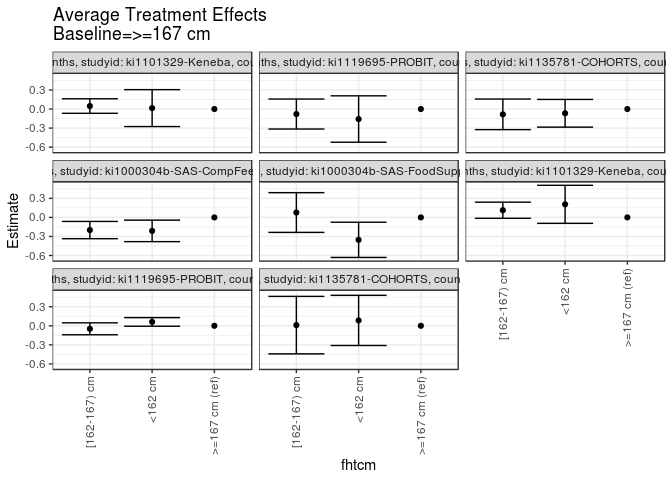

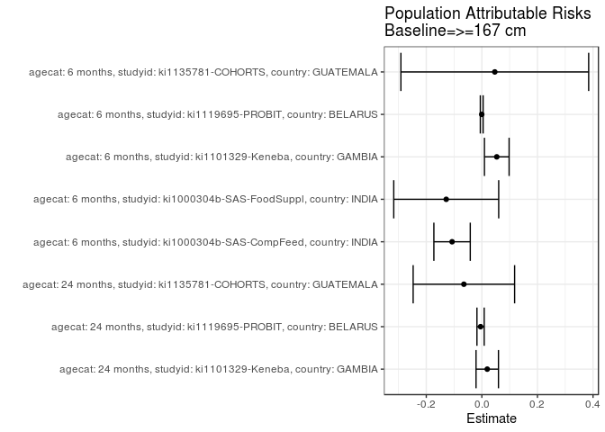

## Results Table

### Parameter: TSM

| agecat | studyid | country | intervention_level | baseline_level | estimate | ci_lower | ci_upper |
| --- | --- | --- | --- | --- | --- | --- | --- |
| 6 months | ki1000304b-SAS-CompFeed | INDIA | >=167 cm | NA | -0.5430942 | -0.7314366 | -0.3547518 |
| 6 months | ki1000304b-SAS-CompFeed | INDIA | <162 cm | NA | -0.7551045 | -0.9665828 | -0.5436262 |
| 6 months | ki1000304b-SAS-CompFeed | INDIA | [162-167) cm | NA | -0.7423303 | -0.8678131 | -0.6168474 |
| 6 months | ki1000304b-SAS-FoodSuppl | INDIA | >=167 cm | NA | -0.8715738 | -1.0817775 | -0.6613701 |
| 6 months | ki1000304b-SAS-FoodSuppl | INDIA | <162 cm | NA | -1.2249771 | -1.4056406 | -1.0443136 |
| 6 months | ki1000304b-SAS-FoodSuppl | INDIA | [162-167) cm | NA | -0.7948516 | -1.0205437 | -0.5691595 |
| 6 months | ki1101329-Keneba | GAMBIA | >=167 cm | NA | -0.2808714 | -0.3534820 | -0.2082608 |
| 6 months | ki1101329-Keneba | GAMBIA | <162 cm | NA | -0.0746977 | -0.3656856 | 0.2162903 |
| 6 months | ki1101329-Keneba | GAMBIA | [162-167) cm | NA | -0.1675878 | -0.2727772 | -0.0623983 |
| 6 months | ki1119695-PROBIT | BELARUS | >=167 cm | NA | 0.5796980 | 0.5207824 | 0.6386136 |
| 6 months | ki1119695-PROBIT | BELARUS | <162 cm | NA | 0.6408082 | 0.5811296 | 0.7004868 |
| 6 months | ki1119695-PROBIT | BELARUS | [162-167) cm | NA | 0.5324059 | 0.4398448 | 0.6249670 |
| 6 months | ki1135781-COHORTS | GUATEMALA | >=167 cm | NA | 0.0443937 | -0.3163272 | 0.4051146 |
| 6 months | ki1135781-COHORTS | GUATEMALA | <162 cm | NA | 0.1289437 | -0.0312415 | 0.2891289 |
| 6 months | ki1135781-COHORTS | GUATEMALA | [162-167) cm | NA | 0.0549795 | -0.2158170 | 0.3257760 |
| 24 months | ki1101329-Keneba | GAMBIA | >=167 cm | NA | -0.8157775 | -0.8836872 | -0.7478678 |
| 24 months | ki1101329-Keneba | GAMBIA | <162 cm | NA | -0.8012432 | -1.0842663 | -0.5182202 |
| 24 months | ki1101329-Keneba | GAMBIA | [162-167) cm | NA | -0.7685378 | -0.8618342 | -0.6752415 |
| 24 months | ki1119695-PROBIT | BELARUS | >=167 cm | NA | 0.6831484 | 0.5727068 | 0.7935899 |
| 24 months | ki1119695-PROBIT | BELARUS | <162 cm | NA | 0.5252517 | 0.1235935 | 0.9269098 |
| 24 months | ki1119695-PROBIT | BELARUS | [162-167) cm | NA | 0.6040508 | 0.3493580 | 0.8587436 |
| 24 months | ki1135781-COHORTS | GUATEMALA | >=167 cm | NA | -0.2355783 | -0.4268530 | -0.0443035 |
| 24 months | ki1135781-COHORTS | GUATEMALA | <162 cm | NA | -0.3025880 | -0.4068858 | -0.1982903 |
| 24 months | ki1135781-COHORTS | GUATEMALA | [162-167) cm | NA | -0.3190631 | -0.4658658 | -0.1722604 |

### Parameter: E(Y)

| agecat | studyid | country | intervention_level | baseline_level | estimate | ci_lower | ci_upper |
| --- | --- | --- | --- | --- | --- | --- | --- |
| 6 months | ki1000304b-SAS-CompFeed | INDIA | NA | NA | -0.6502726 | -0.7957520 | -0.5047932 |
| 6 months | ki1000304b-SAS-FoodSuppl | INDIA | NA | NA | -0.9997844 | -1.1172238 | -0.8823449 |
| 6 months | ki1101329-Keneba | GAMBIA | NA | NA | -0.2272039 | -0.2854286 | -0.1689793 |
| 6 months | ki1119695-PROBIT | BELARUS | NA | NA | 0.5791961 | 0.5216790 | 0.6367132 |
| 6 months | ki1135781-COHORTS | GUATEMALA | NA | NA | 0.0909226 | -0.0348636 | 0.2167089 |
| 24 months | ki1101329-Keneba | GAMBIA | NA | NA | -0.7963776 | -0.8498028 | -0.7429525 |
| 24 months | ki1119695-PROBIT | BELARUS | NA | NA | 0.6785166 | 0.5638515 | 0.7931818 |
| 24 months | ki1135781-COHORTS | GUATEMALA | NA | NA | -0.3002632 | -0.3780672 | -0.2224591 |

### Parameter: ATE

| agecat | studyid | country | intervention_level | baseline_level | estimate | ci_lower | ci_upper |
| --- | --- | --- | --- | --- | --- | --- | --- |
| 6 months | ki1000304b-SAS-CompFeed | INDIA | >=167 cm | >=167 cm | 0.0000000 | 0.0000000 | 0.0000000 |
| 6 months | ki1000304b-SAS-CompFeed | INDIA | <162 cm | >=167 cm | -0.2120103 | -0.3812360 | -0.0427847 |
| 6 months | ki1000304b-SAS-CompFeed | INDIA | [162-167) cm | >=167 cm | -0.1992361 | -0.3349406 | -0.0635315 |
| 6 months | ki1000304b-SAS-FoodSuppl | INDIA | >=167 cm | >=167 cm | 0.0000000 | 0.0000000 | 0.0000000 |
| 6 months | ki1000304b-SAS-FoodSuppl | INDIA | <162 cm | >=167 cm | -0.3534034 | -0.6308998 | -0.0759070 |
| 6 months | ki1000304b-SAS-FoodSuppl | INDIA | [162-167) cm | >=167 cm | 0.0767222 | -0.2362203 | 0.3896647 |
| 6 months | ki1101329-Keneba | GAMBIA | >=167 cm | >=167 cm | 0.0000000 | 0.0000000 | 0.0000000 |
| 6 months | ki1101329-Keneba | GAMBIA | <162 cm | >=167 cm | 0.2061737 | -0.0932611 | 0.5056085 |
| 6 months | ki1101329-Keneba | GAMBIA | [162-167) cm | >=167 cm | 0.1132836 | -0.0138173 | 0.2403845 |
| 6 months | ki1119695-PROBIT | BELARUS | >=167 cm | >=167 cm | 0.0000000 | 0.0000000 | 0.0000000 |
| 6 months | ki1119695-PROBIT | BELARUS | <162 cm | >=167 cm | 0.0611102 | -0.0069221 | 0.1291425 |
| 6 months | ki1119695-PROBIT | BELARUS | [162-167) cm | >=167 cm | -0.0472921 | -0.1414849 | 0.0469007 |
| 6 months | ki1135781-COHORTS | GUATEMALA | >=167 cm | >=167 cm | 0.0000000 | 0.0000000 | 0.0000000 |
| 6 months | ki1135781-COHORTS | GUATEMALA | <162 cm | >=167 cm | 0.0845500 | -0.3105116 | 0.4796116 |
| 6 months | ki1135781-COHORTS | GUATEMALA | [162-167) cm | >=167 cm | 0.0105858 | -0.4419938 | 0.4631655 |
| 24 months | ki1101329-Keneba | GAMBIA | >=167 cm | >=167 cm | 0.0000000 | 0.0000000 | 0.0000000 |
| 24 months | ki1101329-Keneba | GAMBIA | <162 cm | >=167 cm | 0.0145343 | -0.2761643 | 0.3052329 |
| 24 months | ki1101329-Keneba | GAMBIA | [162-167) cm | >=167 cm | 0.0472396 | -0.0670869 | 0.1615662 |
| 24 months | ki1119695-PROBIT | BELARUS | >=167 cm | >=167 cm | 0.0000000 | 0.0000000 | 0.0000000 |
| 24 months | ki1119695-PROBIT | BELARUS | <162 cm | >=167 cm | -0.1578967 | -0.5232471 | 0.2074537 |
| 24 months | ki1119695-PROBIT | BELARUS | [162-167) cm | >=167 cm | -0.0790976 | -0.3153218 | 0.1571267 |
| 24 months | ki1135781-COHORTS | GUATEMALA | >=167 cm | >=167 cm | 0.0000000 | 0.0000000 | 0.0000000 |
| 24 months | ki1135781-COHORTS | GUATEMALA | <162 cm | >=167 cm | -0.0670098 | -0.2849973 | 0.1509778 |
| 24 months | ki1135781-COHORTS | GUATEMALA | [162-167) cm | >=167 cm | -0.0834848 | -0.3245168 | 0.1575472 |

### Parameter: PAR

| agecat | studyid | country | intervention_level | baseline_level | estimate | ci_lower | ci_upper |
| --- | --- | --- | --- | --- | --- | --- | --- |
| 6 months | ki1000304b-SAS-CompFeed | INDIA | >=167 cm | NA | -0.1071784 | -0.1726279 | -0.0417290 |
| 6 months | ki1000304b-SAS-FoodSuppl | INDIA | >=167 cm | NA | -0.1282106 | -0.3170178 | 0.0605966 |
| 6 months | ki1101329-Keneba | GAMBIA | >=167 cm | NA | 0.0536674 | 0.0093112 | 0.0980237 |
| 6 months | ki1119695-PROBIT | BELARUS | >=167 cm | NA | -0.0005019 | -0.0055628 | 0.0045590 |
| 6 months | ki1135781-COHORTS | GUATEMALA | >=167 cm | NA | 0.0465289 | -0.2912635 | 0.3843214 |
| 24 months | ki1101329-Keneba | GAMBIA | >=167 cm | NA | 0.0193999 | -0.0209491 | 0.0597489 |
| 24 months | ki1119695-PROBIT | BELARUS | >=167 cm | NA | -0.0046318 | -0.0176904 | 0.0084268 |
| 24 months | ki1135781-COHORTS | GUATEMALA | >=167 cm | NA | -0.0646849 | -0.2472223 | 0.1178525 |